# The impact of network constraints | AustralianElectricityMarkets.jl

AustralianElectricityMarkets.jl

Appearance

julia

```julia
using AustralianElectricityMarkets
import AustralianElectricityMarkets.RegionModel as RM
using PowerSystems
using PowerSimulations
using HydroPowerSimulations
using Chain
using DataFrames
using AlgebraOfGraphics, CairoMakie
using TidierDB
using Dates
using HiGHS
```

# The impact of network constraints

We previously ignored the network constraints by adopting a "Copper Plate" model. In this zonal model, we will treat each region as a single node (the "Regional Reference Node") and the interconnectors as links between them. This will limit the energy that can be transferred between regions, and lead to different prices across regions once the market is cleared.

While this captures inter-regional congestion, it does not model intra-regional constraints (congestion within a state), which AEMO manages through a process called "Constraint Equations."

## Setup the system

Get the data first!

You will first need to download the data from the monthly archive, saving them locally in parquet files.

julia

```julia
tables = table_requirements(RegionalNetworkConfiguration())
map(tables) do table
    fetch_table_data(table, Date(2025, 1, 1):Date(2025,1,31))
end;
```

julia

```julia
db = aem_connect(duckdb());
```

Instantiate the system.

julia

```julia
sys = nem_system(db, RegionalNetworkConfiguration())
```

| System Property | System Value |
| --- | --- |
| Name |  |
| Description |  |
| System Units Base | SYSTEM_BASE |
| Base Power | 100.0 |
| Base Frequency | 60.0 |
| Num Components | 602 |

| Static Components Type | Static Components Count |
| --- | --- |
| ACBus | 12 |
| Arc | 12 |
| Area | 6 |
| AreaInterchange | 8 |
| EnergyReservoirStorage | 31 |
| HydroDispatch | 84 |
| Line | 14 |
| PowerLoad | 6 |
| RenewableDispatch | 222 |
| ThermalStandard | 199 |
| TransmissionInterface | 8 |

Set the horizon to consider for the simulation.

julia

```julia
interval = Minute(5)
horizon = Hour(24)
start_date = DateTime(2025, 1, 2, 0, 0)
date_range = start_date:interval:(start_date + horizon)
@show date_range
```

```
Dates.DateTime("2025-01-02T00:00:00"):Dates.Minute(5):Dates.DateTime("2025-01-03T00:00:00")
```

Set deterministic time series.

julia

```julia
set_demand!(sys, db, date_range; resolution = interval)
set_renewable_pv!(sys, db, date_range; resolution = interval)
set_renewable_wind!(sys, db, date_range; resolution = interval)
set_hydro_limits!(sys, db, date_range; resolution = interval)
set_market_bids!(sys, db, date_range; resolution = interval)
```

[output not shown]

[output not shown]

[output not shown]

Derive forecasts from the deterministic time series.

julia

```julia
transform_single_time_series!(sys, horizon, interval);
@show sys
```

| System Property | System Value |
| --- | --- |
| Name |  |
| Description |  |
| System Units Base | SYSTEM_BASE |
| Base Power | 100.0 |
| Base Frequency | 60.0 |
| Num Components | 602 |

| Static Components Type | Static Components Count |
| --- | --- |
| ACBus | 12 |
| Arc | 12 |
| Area | 6 |
| AreaInterchange | 8 |
| EnergyReservoirStorage | 31 |
| HydroDispatch | 84 |
| Line | 14 |
| PowerLoad | 6 |
| RenewableDispatch | 222 |
| ThermalStandard | 199 |
| TransmissionInterface | 8 |

| StaticTimeSeries Summary owner_type String | StaticTimeSeries Summary owner_category String | StaticTimeSeries Summary name String | StaticTimeSeries Summary time_series_type String | StaticTimeSeries Summary initial_timestamp String | StaticTimeSeries Summary resolution Dates.CompoundPeriod | StaticTimeSeries Summary count Int64 | StaticTimeSeries Summary time_step_count Int64 |
| --- | --- | --- | --- | --- | --- | --- | --- |
| HydroDispatch | Component | max_active_power | SingleTimeSeries | 2025-01-02T00:00:00 | 5 minutes | 84 | 288 |
| PowerLoad | Component | max_active_power | SingleTimeSeries | 2025-01-02T00:00:00 | 5 minutes | 6 | 288 |
| RenewableDispatch | Component | max_active_power | SingleTimeSeries | 2025-01-02T00:00:00 | 5 minutes | 222 | 288 |

| Forecast Summary owner_type String | Forecast Summary owner_category String | Forecast Summary name String | Forecast Summary time_series_type String | Forecast Summary initial_timestamp String | Forecast Summary resolution Dates.CompoundPeriod | Forecast Summary count Int64 | Forecast Summary horizon Dates.CompoundPeriod | Forecast Summary interval Dates.CompoundPeriod | Forecast Summary window_count Int64 |
| --- | --- | --- | --- | --- | --- | --- | --- | --- | --- |
| EnergyReservoirStorage | Component | decremental_initial_input | Deterministic | 2025-01-02T00:00:00 | 5 minutes | 30 | 1 day | empty period | 1 |
| EnergyReservoirStorage | Component | decremental_variable_cost | Deterministic | 2025-01-02T00:00:00 | 5 minutes | 30 | 1 day | empty period | 1 |
| EnergyReservoirStorage | Component | incremental_initial_input | Deterministic | 2025-01-02T00:00:00 | 5 minutes | 30 | 1 day | empty period | 1 |
| EnergyReservoirStorage | Component | variable_cost | Deterministic | 2025-01-02T00:00:00 | 5 minutes | 30 | 1 day | empty period | 1 |
| HydroDispatch | Component | incremental_initial_input | Deterministic | 2025-01-02T00:00:00 | 5 minutes | 41 | 1 day | empty period | 1 |
| HydroDispatch | Component | max_active_power | DeterministicSingleTimeSeries | 2025-01-02T00:00:00 | 5 minutes | 84 | 1 day | 5 minutes | 1 |
| HydroDispatch | Component | variable_cost | Deterministic | 2025-01-02T00:00:00 | 5 minutes | 41 | 1 day | empty period | 1 |
| PowerLoad | Component | max_active_power | DeterministicSingleTimeSeries | 2025-01-02T00:00:00 | 5 minutes | 6 | 1 day | 5 minutes | 1 |
| RenewableDispatch | Component | incremental_initial_input | Deterministic | 2025-01-02T00:00:00 | 5 minutes | 186 | 1 day | empty period | 1 |
| RenewableDispatch | Component | max_active_power | DeterministicSingleTimeSeries | 2025-01-02T00:00:00 | 5 minutes | 222 | 1 day | 5 minutes | 1 |
| RenewableDispatch | Component | variable_cost | Deterministic | 2025-01-02T00:00:00 | 5 minutes | 186 | 1 day | empty period | 1 |
| ThermalStandard | Component | incremental_initial_input | Deterministic | 2025-01-02T00:00:00 | 5 minutes | 127 | 1 day | empty period | 1 |
| ThermalStandard | Component | variable_cost | Deterministic | 2025-01-02T00:00:00 | 5 minutes | 127 | 1 day | empty period | 1 |

## Set up the problem

julia

```julia
begin
    template = ProblemTemplate()
    set_device_model!(template, Line, StaticBranch)
    set_device_model!(template, PowerLoad, StaticPowerLoad)
    set_device_model!(template, RenewableDispatch, RenewableFullDispatch)
    set_device_model!(template, ThermalStandard, ThermalBasicUnitCommitment)
    set_device_model!(template, HydroDispatch, HydroDispatchRunOfRiver)
    set_network_model!(template, NetworkModel(AreaBalancePowerModel; use_slacks = true))
    set_device_model!(template, AreaInterchange, StaticBranch)
    template
end
```

| Network Model |  |
| --- | --- |
| Network Model | PowerSimulations.AreaBalancePowerModel |
| Slacks | true |
| PTDF | false |
| Duals | None |
| HVDC Network Model | None |

| Device Models Device Type | Device Models Formulation | Device Models Slacks |
| --- | --- | --- |
| PowerSystems.ThermalStandard | PowerSimulations.ThermalBasicUnitCommitment | false |
| PowerSystems.PowerLoad | PowerSimulations.StaticPowerLoad | false |
| PowerSystems.RenewableDispatch | PowerSimulations.RenewableFullDispatch | false |
| PowerSystems.HydroDispatch | HydroPowerSimulations.HydroDispatchRunOfRiver | false |

| Branch Models Branch Type | Branch Models Formulation | Branch Models Slacks |
| --- | --- | --- |
| PowerSystems.AreaInterchange | PowerSimulations.StaticBranch | false |
| PowerSystems.Line | PowerSimulations.StaticBranch | false |

The dispatch problem will be solved with open source solver HiGHS.

julia

```julia
solver = optimizer_with_attributes(HiGHS.Optimizer, "mip_rel_gap" => 0.1)
problem = DecisionModel(template, sys; optimizer = solver, horizon = horizon)
build!(problem; output_dir = joinpath(tempdir(), "out"))
```

```
InfrastructureSystems.Optimization.ModelBuildStatusModule.ModelBuildStatus.BUILT = 0
```

Solve the problem.

julia

```julia
solve!(problem)
```

```
InfrastructureSystems.Simulation.RunStatusModule.RunStatus.SUCCESSFULLY_FINALIZED = 0
```

Observe the results.

julia

```julia
res = OptimizationProblemResults(problem)
```

Start: 2025-01-02T00:00:00

End: 2025-01-02T23:55:00

Resolution: 5 minutes

| PowerSimulations Problem Auxiliary variables Results |
| --- |
| HydroEnergyOutput__HydroDispatch |
| TimeDurationOff__ThermalStandard |
| TimeDurationOn__ThermalStandard |

| PowerSimulations Problem Expressions Results |
| --- |
| ProductionCostExpression__HydroDispatch |
| ProductionCostExpression__RenewableDispatch |
| ActivePowerBalance__Area |
| ProductionCostExpression__ThermalStandard |

| PowerSimulations Problem Parameters Results |
| --- |
| IncrementalPiecewiseLinearBreakpointParameter__RenewableDispatch |
| IncrementalPiecewiseLinearSlopeParameter__ThermalStandard |
| ActivePowerTimeSeriesParameter__HydroDispatch |
| ActivePowerTimeSeriesParameter__RenewableDispatch |
| IncrementalCostAtMinParameter__ThermalStandard |
| IncrementalPiecewiseLinearBreakpointParameter__ThermalStandard |
| IncrementalPiecewiseLinearSlopeParameter__HydroDispatch |
| ActivePowerTimeSeriesParameter__PowerLoad |
| IncrementalPiecewiseLinearBreakpointParameter__HydroDispatch |
| IncrementalPiecewiseLinearSlopeParameter__RenewableDispatch |

| PowerSimulations Problem Variables Results |
| --- |
| SystemBalanceSlackUp__Area |
| StartVariable__ThermalStandard |
| SystemBalanceSlackDown__Area |
| ActivePowerVariable__ThermalStandard |
| StopVariable__ThermalStandard |
| ActivePowerVariable__RenewableDispatch |
| ActivePowerVariable__HydroDispatch |
| OnVariable__ThermalStandard |
| FlowActivePowerVariable__AreaInterchange |

Let's observe how the units are dispatched.

julia

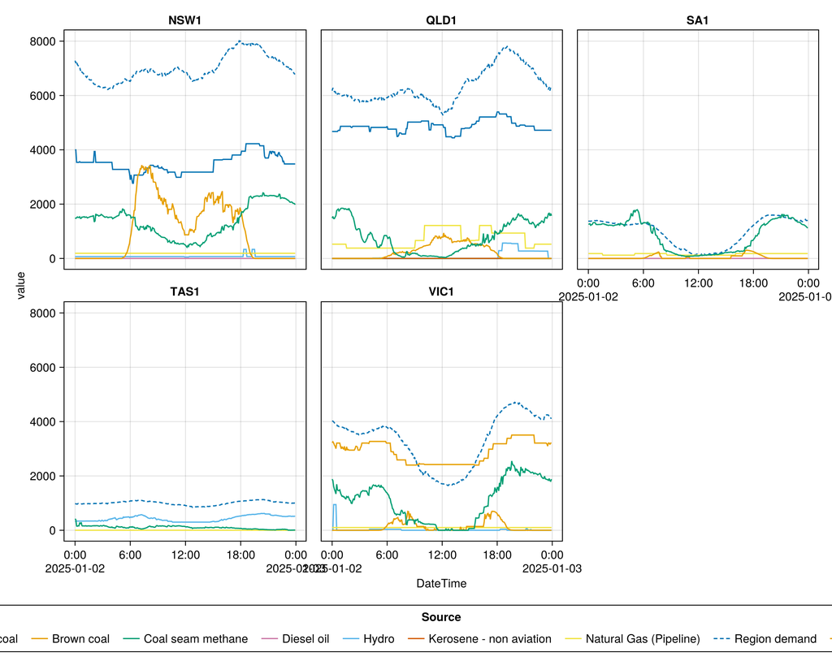

```julia
begin
    function filter_non_all_zero(df, group_by)
        gdf = groupby(df, group_by)
        is_all_zero = combine(gdf, :value => (x -> all(x == 0)) => :all_zero)
        subset!(is_all_zero, :all_zero => x -> .!x)
        return innerjoin(df, is_all_zero, on = group_by)
    end

    renewables = read_variable(res, "ActivePowerVariable__RenewableDispatch")
    thermal = read_variable(res, "ActivePowerVariable__ThermalStandard")
    hydro = read_variable(res, "ActivePowerVariable__HydroDispatch")
    gens_long = vcat(renewables, thermal, hydro)
    select!(gens_long, :DateTime, :name => :DUID, :value)

    by_fuel = @chain select(
        read_units(db),
        [:DUID, :STATIONID, :CO2E_ENERGY_SOURCE, :REGIONID]
    ) begin
        rightjoin(gens_long, on = :DUID)
        groupby([:CO2E_ENERGY_SOURCE, :REGIONID, :DateTime])
        combine(:value => sum => :value)
        dropmissing!
        select!(:DateTime, :REGIONID, :CO2E_ENERGY_SOURCE => :Source, :value)
        filter_non_all_zero([:REGIONID, :Source])
    end

    loads = @chain res begin
        read_parameter("ActivePowerTimeSeriesParameter__PowerLoad")
        transform!(:name => ByRow(x -> split(x, " ")[1]) => :REGIONID)
        subset!(:REGIONID => ByRow(!=("SNOWY1")))
        insertcols!(:Source => "Region demand")
        select!(:DateTime, :REGIONID, :Source, :value => ByRow(-) => :value)
    end

    demand = data(loads) * mapping(:DateTime, :value, color = :Source, layout = :REGIONID) * visual(Lines, linestyle = (:dash, :dense))
    generation = data(by_fuel) * mapping(:DateTime, :value, color = :Source, layout = :REGIONID) * visual(Lines)
    draw(demand + generation; figure = (; size = (1000, 800)), legend = (; position = :bottom))
end
```

Let's observe the dispatch of a few thermal generators.

julia

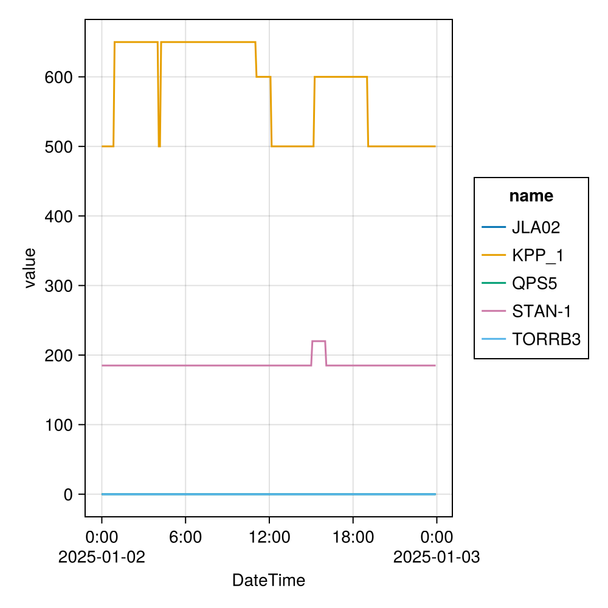

```julia
begin
    thermals_non_zero = filter_non_all_zero(thermal, :name)
    sample = first(unique(thermals_non_zero.name), 5)
    sample = subset!(thermals_non_zero, :name => ByRow(in(sample)))
    spec = data(sample) * mapping(:DateTime, :value, color = :name) * visual(Lines)
    draw(spec; figure = (; size = (500, 500)))
end
```

Let's observe the dispatch of a few renewable generators.

julia

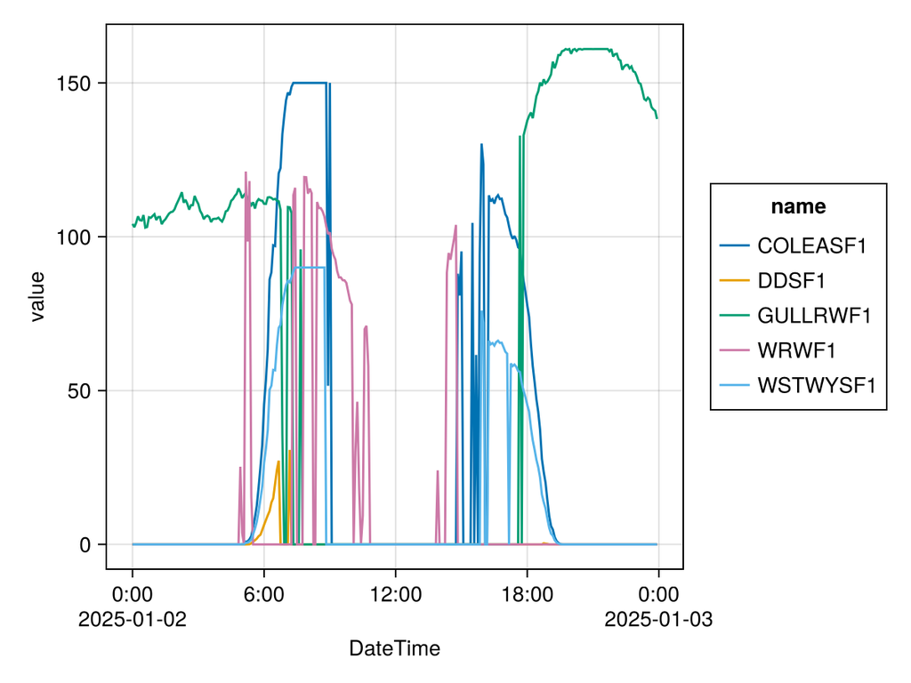

```julia
begin
    renewables_non_zero = filter_non_all_zero(renewables, :name)
    sample = first(unique(renewables_non_zero.name), 5)
    sample = subset!(renewables_non_zero, :name => ByRow(in(sample)))
    data(sample) * mapping(:DateTime, :value, color = :name) * visual(Lines) |> draw
end
```

Notice that most solar generators are actually **not** dispatched during the day here even though the solar output is definitely non-zero.

julia

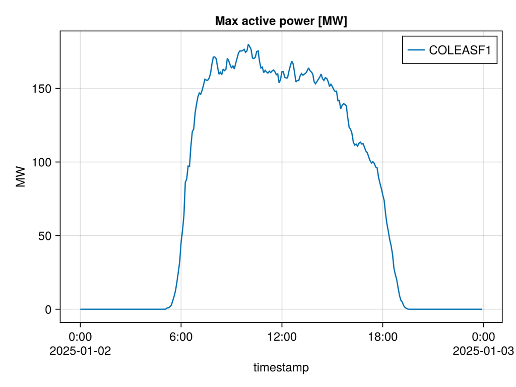

```julia
begin
    ren = get_component(RenewableDispatch, sys, "COLEASF1")
    ts = get_time_series_array(Deterministic, ren, "max_active_power") |> DataFrame
    index, values = ts.timestamp, ts.A * 100
    fig = Figure()
    ax = Axis(fig[1, 1], xlabel = "timestamp", title = "Max active power [MW]", ylabel = "MW")
    lines!(index, values; label = "COLEASF1")
    axislegend(ax)
    fig
end
```

In the NEM, interconnectors are vital for sharing resources between states. However, when an interconnector reaches its limit (becomes saturated), the regions on either side can have different clearing prices. This **Price Separation** is a key feature of the NEM's regional structure. Let's observe the interchange flows and how close they operate to their limits.

julia

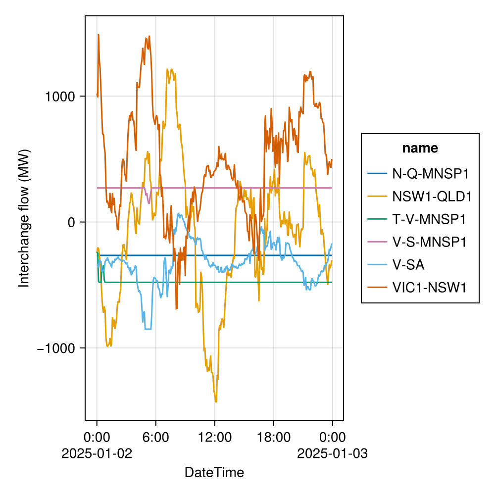

```julia
begin
    interchange_flow = read_variable(res, "FlowActivePowerVariable__AreaInterchange")
    spec = data(interchange_flow) * mapping(:DateTime, :value => "Interchange flow (MW)", color = :name) * visual(Lines)
    draw(spec; figure = (; size = (500, 500)))
end
```

We see that a few lines are often saturated: V-S-MNSP1 connecting Victoria and South Australia, or T-V-MSP1 connecting Victoria and Tasmania. The interfaces between New South Wales and Queensland, and New South Wales and Victoria are operated within their bounds and the power flows in both directions depending on the time of the day and resources available.